# Exercise 1

Adam Lu

2018/3/12

```r
library(dplyr)
library(survival)
library(survminer)
```

Take a look at the built in `colon` dataset. If you type `?colon` it’ll ask you if you wanted help on the colon dataset from the survival package, or the colon operator. Click “Chemotherapy for Stage B/C colon cancer”, or be specific with `?survival::colon`. This dataset has survival and recurrence information on 929 people from a clinical trial on colon cancer chemotherapy. There are two rows per person, indicated by the event type (`etype`) variable – `etype == 1` indicates that row corresponds to recurrence; `etype == 2` indicates death.

First, let’s turn the `colon` data into a tibble, then filter the data to only include the survival data, not the recurrence data. Let’s call this new object `colondeath`. The `filter()` function is in the `dplyr` library, which you can get by running `library(dplyr)`. If you don’t have dplyr you can use the base `subset()` function instead.

```r
colon <- as_tibble(colon)
colon
```

```
## # A tibble: 1,858 x 16
##       id study rx        sex   age obstruct perfor adhere nodes status
##  * <dbl> <dbl> <fct>   <dbl> <dbl>    <dbl>  <dbl>  <dbl> <dbl>  <dbl>
##  1  1.00  1.00 Lev+5FU  1.00  43.0     0         0   0     5.00   1.00
##  2  1.00  1.00 Lev+5FU  1.00  43.0     0         0   0     5.00   1.00
##  3  2.00  1.00 Lev+5FU  1.00  63.0     0         0   0     1.00   0
##  4  2.00  1.00 Lev+5FU  1.00  63.0     0         0   0     1.00   0
##  5  3.00  1.00 Obs      0     71.0     0         0   1.00  7.00   1.00
##  6  3.00  1.00 Obs      0     71.0     0         0   1.00  7.00   1.00
##  7  4.00  1.00 Lev+5FU  0     66.0     1.00      0   0     6.00   1.00
##  8  4.00  1.00 Lev+5FU  0     66.0     1.00      0   0     6.00   1.00
##  9  5.00  1.00 Obs      1.00  69.0     0         0   0    22.0    1.00
## 10  5.00  1.00 Obs      1.00  69.0     0         0   0    22.0    1.00
## # ... with 1,848 more rows, and 6 more variables: differ <dbl>,
## #   extent <dbl>, surg <dbl>, node4 <dbl>, time <dbl>, etype <dbl>
```

```r
colondeath <- filter(colon, etype == 2)
colondeath
```

```
## # A tibble: 929 x 16
##       id study rx        sex   age obstruct perfor adhere nodes status
##    <dbl> <dbl> <fct>   <dbl> <dbl>    <dbl>  <dbl>  <dbl> <dbl>  <dbl>
##  1  1.00  1.00 Lev+5FU  1.00  43.0     0         0   0     5.00   1.00
##  2  2.00  1.00 Lev+5FU  1.00  63.0     0         0   0     1.00   0
##  3  3.00  1.00 Obs      0     71.0     0         0   1.00  7.00   1.00
##  4  4.00  1.00 Lev+5FU  0     66.0     1.00      0   0     6.00   1.00
##  5  5.00  1.00 Obs      1.00  69.0     0         0   0    22.0    1.00
##  6  6.00  1.00 Lev+5FU  0     57.0     0         0   0     9.00   1.00
##  7  7.00  1.00 Lev      1.00  77.0     0         0   0     5.00   1.00
##  8  8.00  1.00 Obs      1.00  54.0     0         0   0     1.00   0
##  9  9.00  1.00 Lev      1.00  46.0     0         0   1.00  2.00   0
## 10 10.0   1.00 Lev+5FU  0     68.0     0         0   0     1.00   0
## # ... with 919 more rows, and 6 more variables: differ <dbl>,
## #   extent <dbl>, surg <dbl>, node4 <dbl>, time <dbl>, etype <dbl>
```

```r
# Or, using base subset()
# colondeath <- subset(colon, etype == 2)

head(colondeath)
```

```
## # A tibble: 6 x 16
##      id study rx      sex   age obstruct perfor adhere nodes status differ
##   <dbl> <dbl> <fct> <dbl> <dbl>    <dbl>  <dbl>  <dbl> <dbl>  <dbl>  <dbl>
## 1  1.00  1.00 Lev+~  1.00  43.0     0         0   0     5.00   1.00   2.00
## 2  2.00  1.00 Lev+~  1.00  63.0     0         0   0     1.00   0      2.00
## 3  3.00  1.00 Obs    0     71.0     0         0   1.00  7.00   1.00   2.00
## 4  4.00  1.00 Lev+~  0     66.0     1.00      0   0     6.00   1.00   2.00
## 5  5.00  1.00 Obs    1.00  69.0     0         0   0    22.0    1.00   2.00
## 6  6.00  1.00 Lev+~  0     57.0     0         0   0     9.00   1.00   2.00
## # ... with 5 more variables: extent <dbl>, surg <dbl>, node4 <dbl>,
## #   time <dbl>, etype <dbl>
```

1. Look at the help for `?colon` again. How are `sex` and `status` coded? How is this different from the lung data?

```r
?survival::colon
head(colon$sex)
head(colon$status)
```

[output not shown]

2. Using `survfit(Surv(..., ...,)~..., data=colondeath)`, create a survival curve separately for males versus females. Call the resulting object `sfit`. Run a `summary()` on this object, showing time points 0, 500, 1000, 1500, and 2000. Do males or females appear to fair better over this time period?

```r
sfit1 <- survfit(Surv(time, status) ~ sex, data = colondeath)
summary(sfit1, times = seq(0, 2000, 500))
```

```
## Call: survfit(formula = Surv(time, status) ~ sex, data = colondeath)
##
##                 sex=0
##  time n.risk n.event survival std.err lower 95% CI upper 95% CI
##     0    445       0    1.000  0.0000        1.000        1.000
##   500    381      64    0.856  0.0166        0.824        0.889
##  1000    306      75    0.688  0.0220        0.646        0.732
##  1500    265      40    0.598  0.0232        0.554        0.645
##  2000    218      22    0.547  0.0236        0.503        0.596
##
##                 sex=1
##  time n.risk n.event survival std.err lower 95% CI upper 95% CI
##     0    484       0    1.000  0.0000        1.000        1.000
##   500    418      65    0.866  0.0155        0.836        0.897
##  1000    335      83    0.694  0.0210        0.654        0.736
##  1500    287      46    0.598  0.0223        0.556        0.644
##  2000    238      25    0.545  0.0227        0.503        0.592
```

```
Answer: The survival curves are about the same.
```

3. Using the survminer package, plot a Kaplan-Meier curve for this analysis with confidence intervals and showing the p-value. See `?ggsurvplot` for help. Is there a significant difference between males and females?

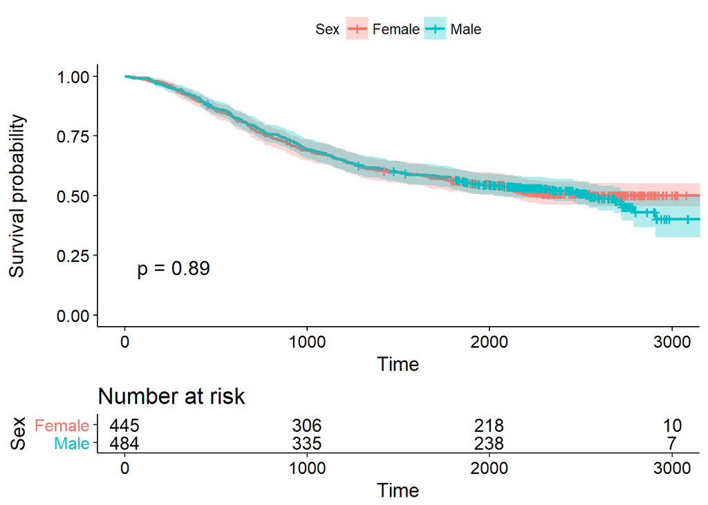

```r
ggsurvplot(sfit1, conf.int = TRUE, pval = TRUE,
           legend.labs = c("Female", "Male"),
           risk.table = TRUE, legend.title = "Sex")
```

```r
#           title("Kaplan-Meier Curve for Colon Cancer Survival")
```

```
Answer: There is no significant difference between males and females.
```

4. Create Kaplan-Meier plot stratifying by:
1. The extent of differentiation (well, moderate, poor), showing the p-value.

```r
sfit2 <- survfit(Surv(time, status) ~ differ, data = colondeath)
summary(sfit2, times = seq(0, 2000, 500))
```

```
## Call: survfit(formula = Surv(time, status) ~ differ, data = colondeath)
##
## 23 observations deleted due to missingness
##                 differ=1
##  time n.risk n.event survival std.err lower 95% CI upper 95% CI
##     0     93       0    1.000  0.0000        1.000        1.000
##   500     85       8    0.914  0.0291        0.859        0.973
##  1000     70      15    0.753  0.0447        0.670        0.846
##  1500     55      15    0.591  0.0510        0.499        0.700
##  2000     49       3    0.559  0.0515        0.467        0.670
##
##                 differ=2
##  time n.risk n.event survival std.err lower 95% CI upper 95% CI
##     0    663       0    1.000  0.0000        1.000        1.000
##   500    585      78    0.882  0.0125        0.858        0.907
##  1000    476     109    0.718  0.0175        0.684        0.753
##  1500    415      58    0.630  0.0188        0.595        0.668
##  2000    340      36    0.575  0.0193        0.538        0.614
##
##                 differ=3
##  time n.risk n.event survival std.err lower 95% CI upper 95% CI
##     0    150       0    1.000  0.0000        1.000        1.000
##   500    108      41    0.726  0.0364        0.658        0.801
##  1000     78      30    0.525  0.0409        0.450        0.611
##  1500     66      12    0.444  0.0407        0.371        0.531
##  2000     57       4    0.417  0.0404        0.345        0.504
```

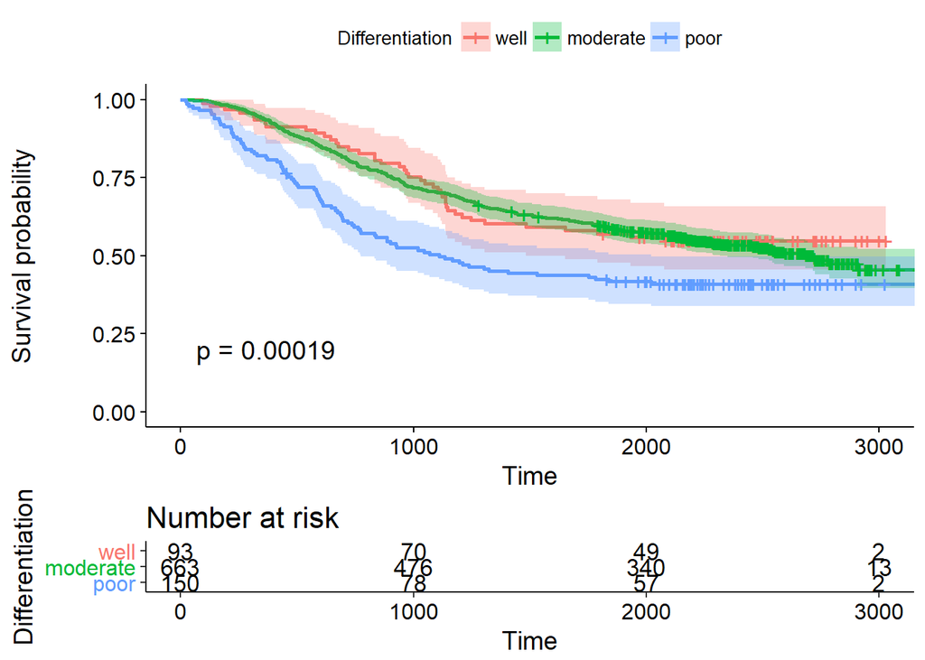

```r
ggsurvplot(sfit2, conf.int = TRUE, pval = TRUE,
           legend.labs = c("well", "moderate", "poor"),
           risk.table = TRUE, legend.title = "Differentiation")
```

```r
#           title("Kaplan-Meier Curve for Colon Cancer Survival")
```

Whether or not there was detectable cancer in >=4 lymph nodes, showing the p-value and confidence bands.

```r
sfit3 <- survfit(Surv(time, status) ~ node4, data = colondeath)
summary(sfit3, times = seq(0, 2000, 500))
```

```
## Call: survfit(formula = Surv(time, status) ~ node4, data = colondeath)
##
##                 node4=0
##  time n.risk n.event survival std.err lower 95% CI upper 95% CI
##     0    674       0    1.000  0.0000        1.000        1.000
##   500    616      57    0.915  0.0107        0.895        0.937
##  1000    519      97    0.771  0.0162        0.740        0.804
##  1500    458      58    0.685  0.0179        0.651        0.721
##  2000    388      33    0.635  0.0186        0.599        0.672
##
##                 node4=1
##  time n.risk n.event survival std.err lower 95% CI upper 95% CI
##     0    255       0    1.000  0.0000        1.000        1.000
##   500    183      72    0.718  0.0282        0.664        0.775
##  1000    122      61    0.478  0.0313        0.421        0.544
##  1500     94      28    0.369  0.0302        0.314        0.433
##  2000     68      14    0.313  0.0291        0.260        0.375
```

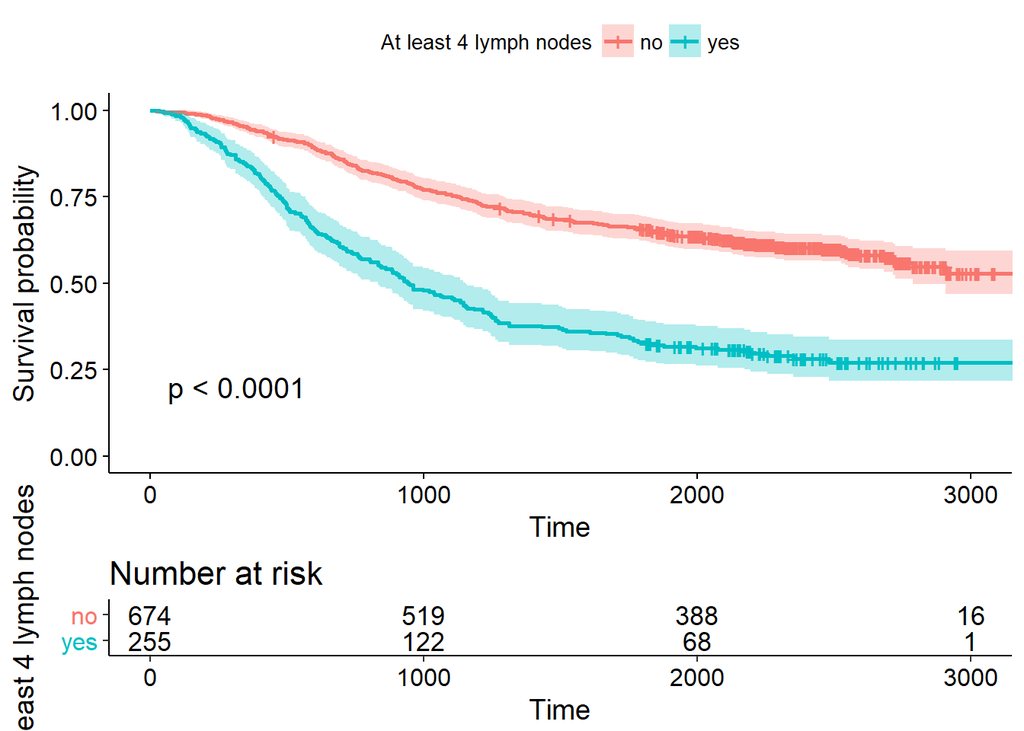

```r
ggsurvplot(sfit3, conf.int = TRUE, pval = TRUE,
           legend.labs = c("no", "yes"),
           risk.table = TRUE, legend.title = "At least 4 lymph nodes")
```

```r
#           title("Kaplan-Meier Curve for Colon Cancer Survival")
```

Don’t do this:

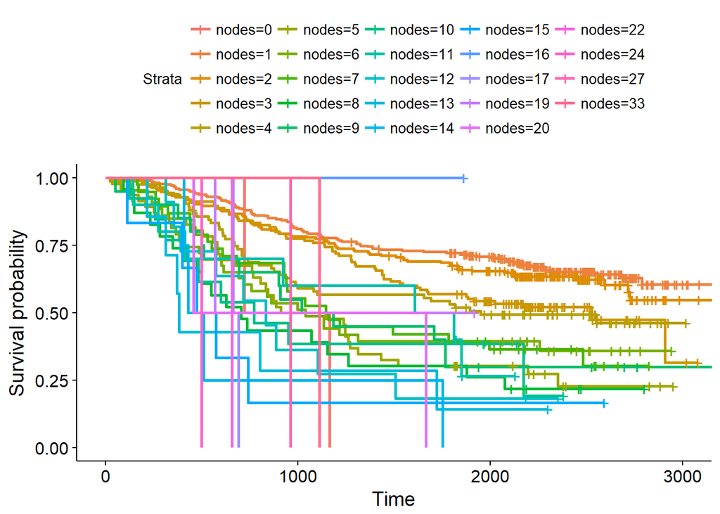

```r
sfit4 <- survfit(Surv(time, status) ~ nodes, data = colondeath)
ggsurvplot(sfit4)
```